# Day 3 Lab Key

Christopher Loan

2023-01-26

# Instructions:

set seed to `022023`

Load

- `tidyverse`
- `rsample`
- `ranger`
- `dials`

Import the key & se asian data as `key` and `dat`, respectively.

```r
set.seed(022023)
library(tidyverse)
library(rsample)
library(ranger)
library(dials)

key <-
  read.csv(here::here('data/keys', 'key_impute.csv'))

dat <-
  read.csv(
    here::here(
      'data',
      'se_asia_imputed_world_bank.csv'
    )
  )
```

split the data into training and testing with `initial_split()`, `training()` and `testing()`.

Make sure your split specified `country_name` as the `strata`.

```r
sea_split <- initial_split(dat, strata = country_name)
sea_training <- training(sea_split)
sea_testing <- testing(sea_split)
```

# Goals

- Establish at least one benchmark for predicting: `st_int_arvl`
- Calculate MSE for that benchmark
- Attempt to fit an RF which can outperform your benchmark

`st_int_arvl` = International tourism, number of arrivals

# Choosing a Benchmark

Measures of central tendency (i.e., mean, median, mode) tend to be good first-pass benchmarks.

Use this code to plot the values.

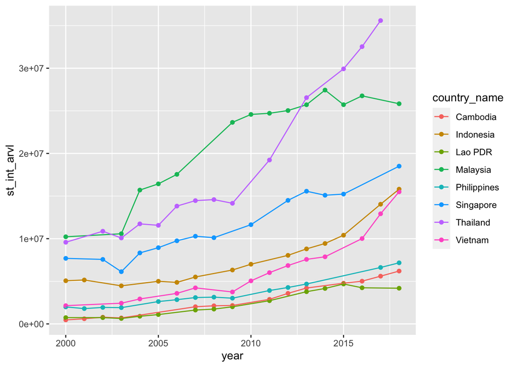

```r
int_arvl_plt <-
  sea_training %>%
  ggplot(
    aes(
      y = st_int_arvl,
      x = year,
      color = country_name
    )
  ) +
  geom_point() +
  geom_line()
int_arvl_plt
```

Calculate the mean and median of `st_int_arvl` within the training data, and store them as `training_arvl_mean` and `training_arvl_median`, respectively.

```r
training_arvl_mean <- mean(sea_training$st_int_arvl)
training_arvl_median <- median(sea_training$st_int_arvl)
```

Use `+ geom_hline(yintercept = training_arvl_mean)` to add a horizontal line at the mean.

In the same plot, add a horizontal line at the median, except add the argument `linetype = 2` to the `geom_hline()` function (this makes a dashed line to tell the difference)

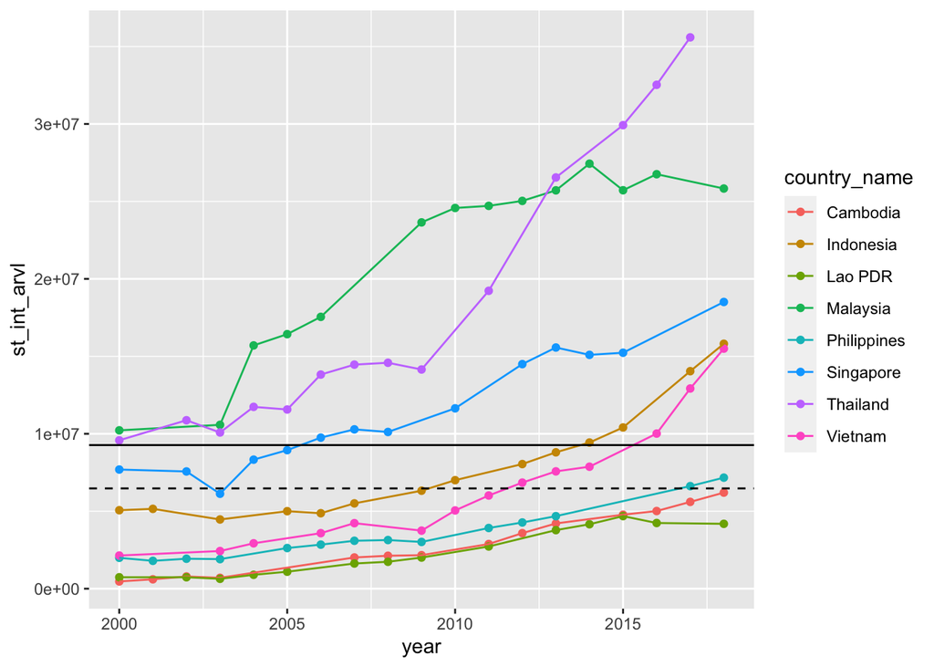

```r
int_arvl_plt +
  geom_hline(yintercept = training_arvl_mean) +
  geom_hline(yintercept = training_arvl_median, linetype = 2)
```

Which model do you prefer as your benchmark?

**Answer will vary; there are reasonable arguments for either**

Why?

**Answer will vary; there are reasonable arguments for either**

# Establish Ranges for Tuning

store the number of predictor variables in the `sea_training` as a variable called `p`.

*HINT:* `sea_training` contains predictors and the outcome, so be sure to subtract 1 from the number of columns in `sea_training`

```r
p <- ncol(sea_training)-1
```

# Make a maximum entropy grid

Instead of searching an expanded grid, create a maximum entropy grid.

Use the same minimum and maximum values we used to tune `mtry` and `num.trees`

To keep computation time quick, set `size = 200`.

(Ideally, we would use more than 200, but this is just for an example.)

**NOTE:** If this still takes a long time, you can use a smaller range for the sake of the example.

```r
max_entropy_grid <-
  grid_max_entropy(
    # param object 1:  `trees`
    trees(range = c(p*10, p*50)),
    # param object 2: `mtry`
    mtry(range = c(2, round(p/2))),
    size = 200
  )
```

# Fit Random Forests in a Loop

Using the code we made together as an example, fit random forests in a loop.

Store OOB prediction error for each model.

```r
# make empty list to store fitted RF & MSE
rfs_tmp <- list()
mses_tmp <- list()

for (i in 1:nrow(max_entropy_grid)){

# fit RF for each hyperparameter state
  rfs_tmp[[i]] <-
    ranger(
      data = sea_training,
      formula =  st_int_arvl ~ .,
      mtry = max_entropy_grid$mtry[[i]],
      num.trees = max_entropy_grid$trees[[i]]
    )

# store MSE
  mses_tmp[[i]] <- rfs_tmp[[i]]$prediction.error
}
```

### Pull Best Value

Select the model with the lowest OOB prediction error.

```r
best_i <- which.min(mses_tmp)
```

# Assess Fit of Best Model

Using unseen testing data, calculate the MSE of your benchmark model and your tuned model.

**HINT:** Refer to the workshop slides to get code for calculating MSE.

```r
mse <- function(observed_y, predicted_y){
    (sum(observed_y - predicted_y)^2)/length(observed_y)
}
```

## Benchmark MSE

```r
mse(
  observed_y = sea_testing$st_int_arvl,
  predicted_y = mean(sea_training$st_int_arvl)
)
```

```
## [1] 27205538297
```

## Best RF MSE

```r
mse(
  observed_y = sea_testing$st_int_arvl,
  predicted_y =
    predict(rfs_tmp[[best_i]], data = sea_testing)$predictions
)
```

```
## [1] 394354096
```

## Which model performs better?

The tuned model outperforms the benchmark

# If time permits:

Find another model predicts international arrival better than this model.

Here are a few suggestions (but there are many other possibilites)

- using a larger maximum entropy grid
- tune a wider range of hyperparameters
- tuning additional variables